# Distributions

Dr. B

Tuesday, December 30, 2014

## Overview

For every distribution there are four commands. The commands for each distribution are prepended with a letter to indicate the functionality:

“d” returns the height of the probability density function

“p” returns the cumulative density function

“q” returns the inverse cumulative density function (quantiles)

“r” returns randomly generated numbers

### Normal Distribution

#### dnorm

Given a set of values, dnorm returns the height of the probability distribution at each point. If you only give the points, dnorm assumes you want to use a mean of zero and standard deviation of one. There are options to use different values for the mean and standard deviation:

```r
dnorm(0)
```

```
## [1] 0.3989423
```

```r
dnorm(0)*sqrt(2*pi)
```

```
## [1] 1
```

```r
dnorm(0,mean=4)
```

```
## [1] 0.0001338302
```

```r
dnorm(0,mean=4,sd=10)
```

```
## [1] 0.03682701
```

```r
v <- c(0,1,2)
dnorm(v)
```

```
## [1] 0.39894228 0.24197072 0.05399097
```

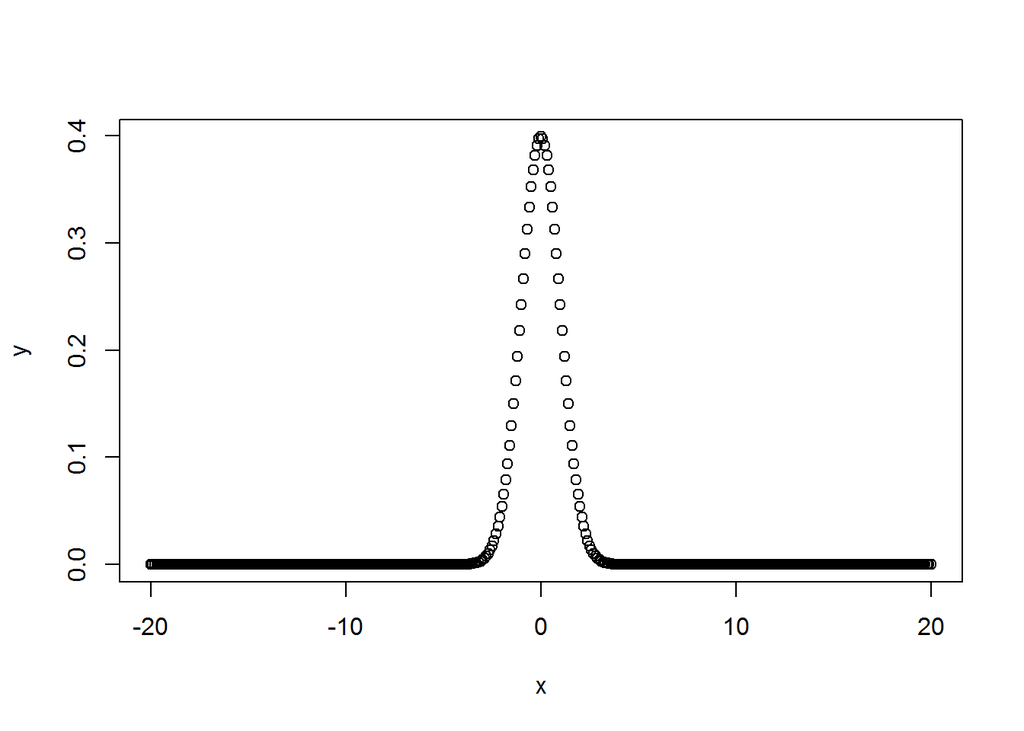

```r
x <- seq(-20,20,by=.1)
y <- dnorm(x)
plot(x,y)
```

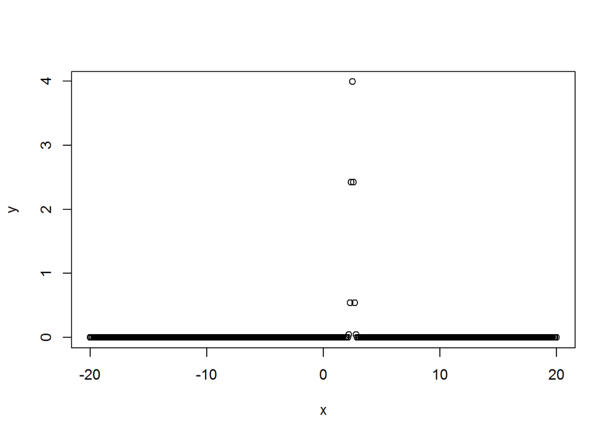

```r
y <- dnorm(x,mean=2.5,sd=0.1)
plot(x,y)
```

#### pnorm

Given a number or a list, pnorm computes the probability that a normally distributed random number will be less than that number. pnorm is also known as the “Cumulative Distribution Function.” It accepts the same options as dnorm:

```r
pnorm(0)
```

```
## [1] 0.5
```

```r
pnorm(1)
```

```
## [1] 0.8413447
```

```r
pnorm(0,mean=2)
```

```
## [1] 0.02275013
```

```r
pnorm(0,mean=2,sd=3)
```

```
## [1] 0.2524925
```

```r
v <- c(0,1,2)
pnorm(v)
```

```
## [1] 0.5000000 0.8413447 0.9772499
```

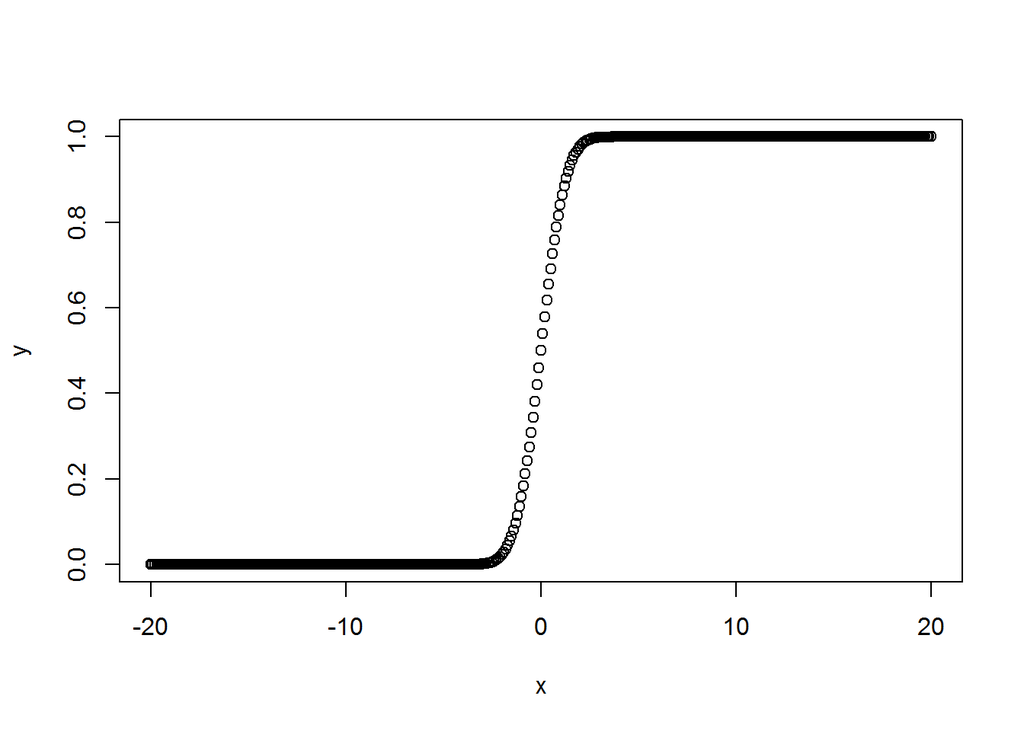

```r
x <- seq(-20,20,by=.1)
y <- pnorm(x)
plot(x,y)
```

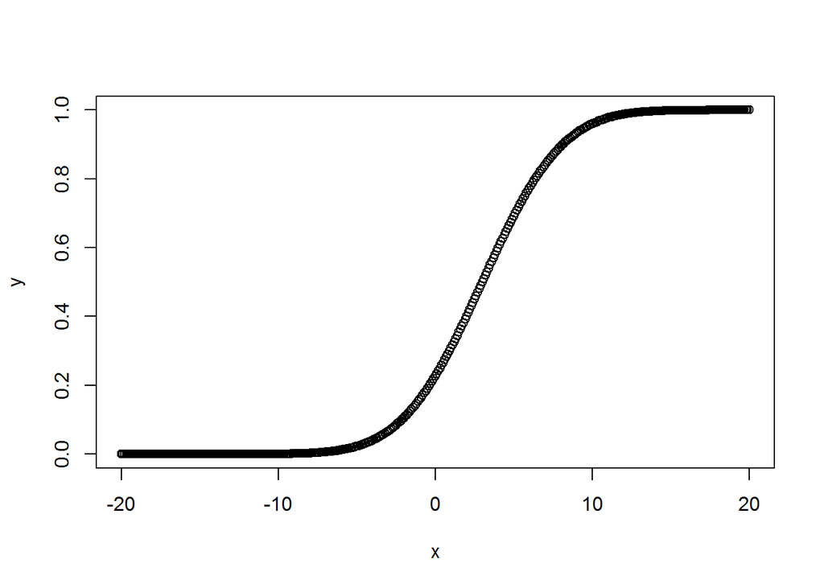

```r
y <- pnorm(x,mean=3,sd=4)
plot(x,y)
```

If you wish to find the probability that a number is larger than the given number, you can use the lower.tail option:

```r
pnorm(0,lower.tail=FALSE)
```

```
## [1] 0.5
```

```r
pnorm(1,lower.tail=FALSE)
```

```
## [1] 0.1586553
```

```r
pnorm(0,mean=2,lower.tail=FALSE)
```

```
## [1] 0.9772499
```

#### qnorm

The qnorm function is the inverse of pnorm. The idea behind qnorm is that you give it a probability, and it returns the number whose cumulative distribution matches the probability. For example, if you have a normally distributed random variable with mean zero and standard deviation one, then if you give the function a probability it returns the associated Z-score:

```r
qnorm(0.5)
```

```
## [1] 0
```

```r
qnorm(0.5,mean=1)
```

```
## [1] 1
```

```r
qnorm(0.5,mean=1,sd=2)
```

```
## [1] 1
```

```r
qnorm(0.5,mean=2,sd=2)
```

```
## [1] 2
```

```r
qnorm(0.5,mean=2,sd=4)
```

```
## [1] 2
```

```r
qnorm(0.25,mean=2,sd=2)
```

```
## [1] 0.6510205
```

```r
qnorm(0.333)
```

```
## [1] -0.4316442
```

```r
qnorm(0.333,sd=3)
```

```
## [1] -1.294933
```

```r
qnorm(0.75,mean=5,sd=2)
```

```
## [1] 6.34898
```

```r
v = c(0.1,0.3,0.75)
qnorm(v)
```

```
## [1] -1.2815516 -0.5244005  0.6744898
```

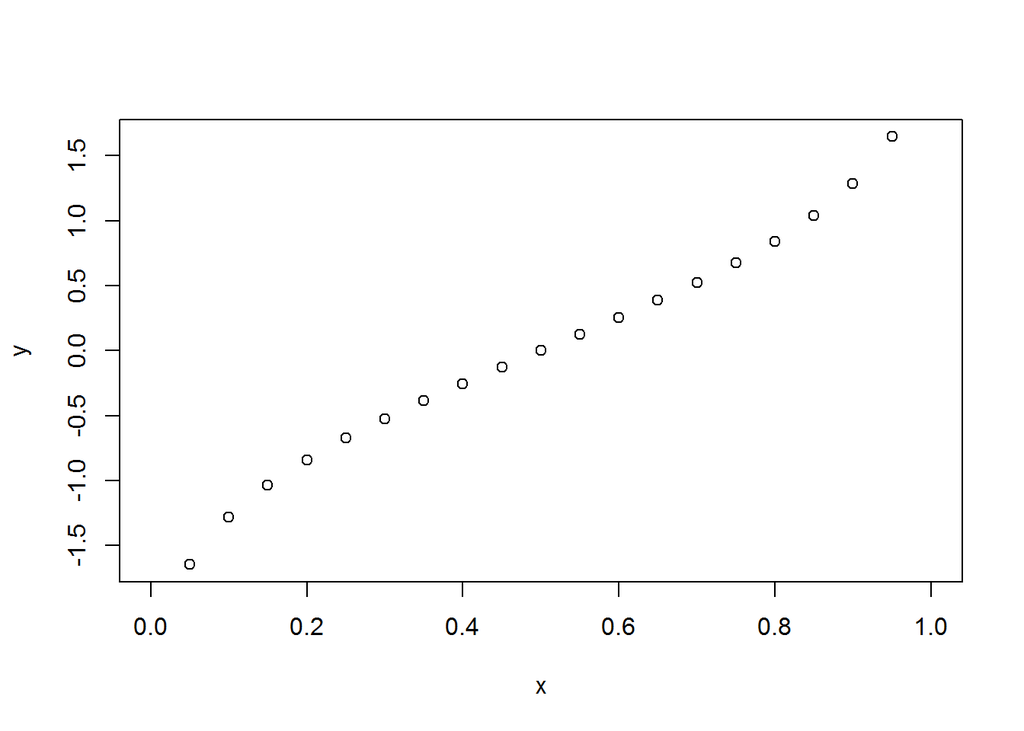

```r
x <- seq(0,1,by=.05)
y <- qnorm(x)
plot(x,y)
```

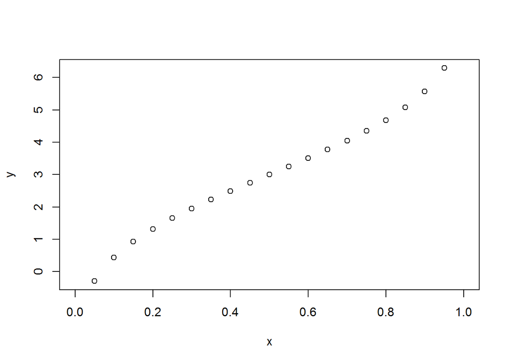

```r
y <- qnorm(x,mean=3,sd=2)
plot(x,y)
```

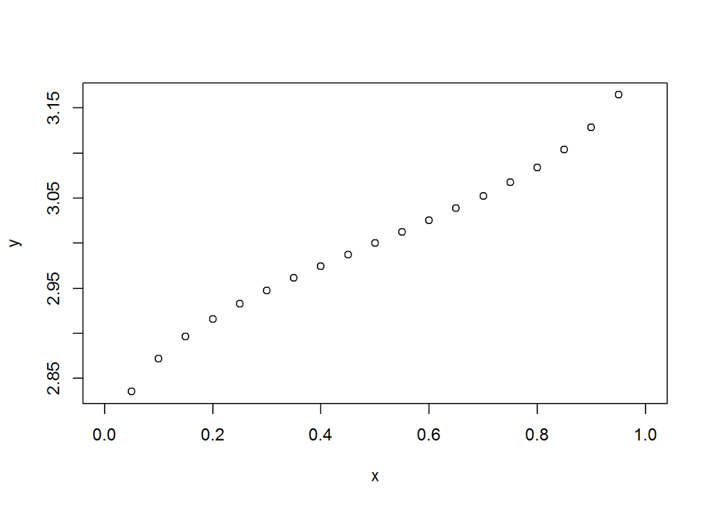

```r
y <- qnorm(x,mean=3,sd=0.1)
plot(x,y)
```

#### rnorm

The rnorm function can generate random numbers whose distribution is normal. The argument that you give it is the number of random numbers that you want, and it has optional arguments to specify the mean and standard deviation:

```r
rnorm(4)
```

```
## [1]  1.9856062 -2.4071295 -0.1611756 -0.4851647
```

```r
rnorm(4,mean=3)
```

```
## [1] 4.869284 3.128422 2.190344 1.860953
```

```r
rnorm(4,mean=3,sd=3)
```

```
## [1] 5.831692 3.340367 6.979096 4.745324
```

```r
rnorm(4,mean=3,sd=3)
```

```
## [1] -0.3247185  5.5170198  2.2269799  4.1512687
```

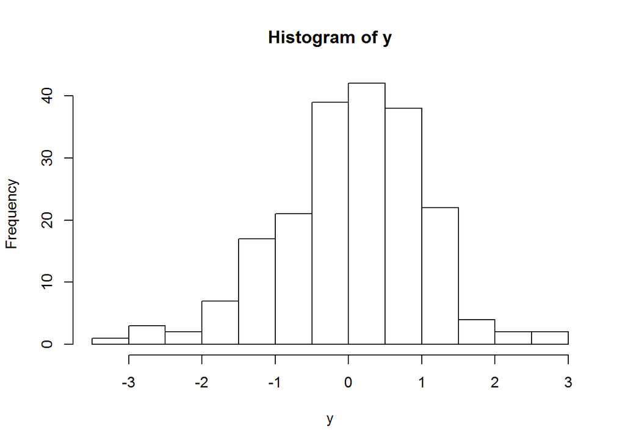

```r
y <- rnorm(200)
hist(y)
```

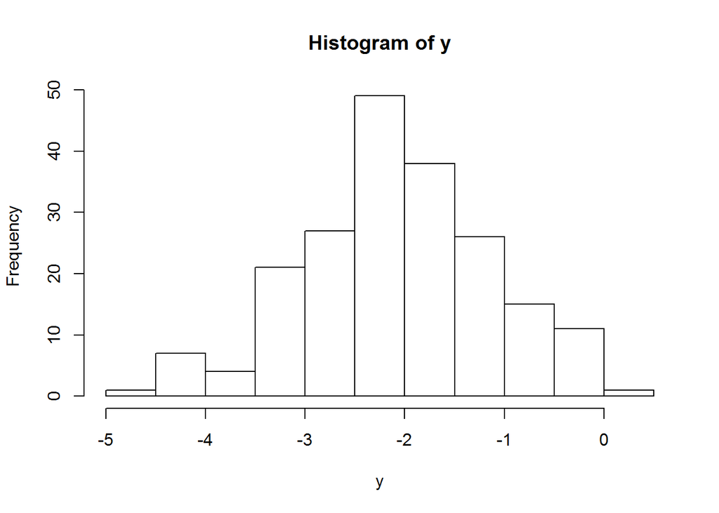

```r
y <- rnorm(200,mean=-2)
hist(y)
```

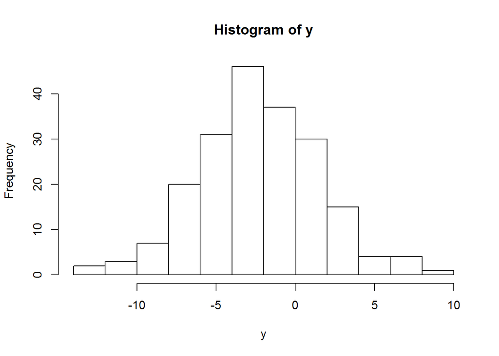

```r
y <- rnorm(200,mean=-2,sd=4)
hist(y)
```

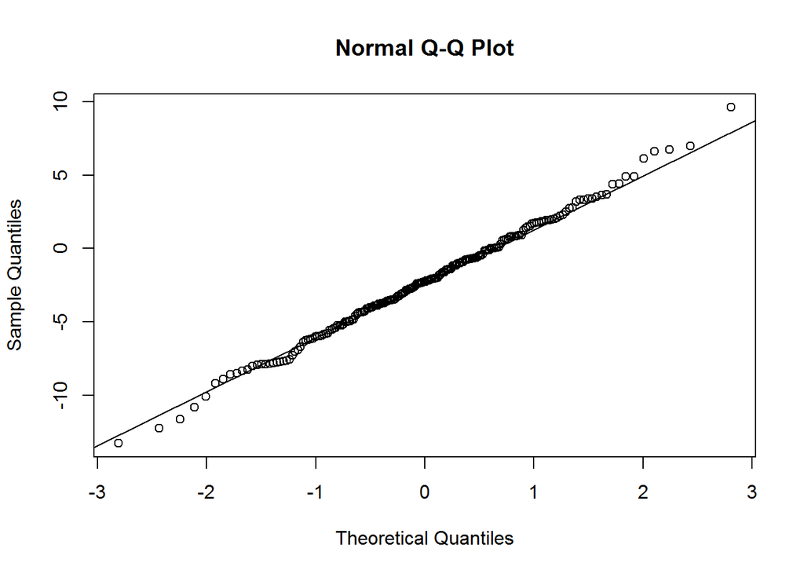

```r
qqnorm(y)
qqline(y)
```